# dtm002 161..182

Converted from PDF `Coucke-LayoffsRestructuringModes-2007-ICC.pdf` · 22 pages · anchors: page `#pN`, block `#pN-bK`

Page 1

Industrial and Corporate Change, Volume 16, Number 2, pp. 161–182 doi:10.1093/icc/dtm002 Advance Access published April 29, 2007

## Employee layoff under different modes of restructuring: exit, downsizing or relocation

Kristien Coucke, Enrico Pennings and Leo Sleuwaegen

Pressured by globalizing economies and growing international competition,

an increasing number of firms are forced to rationalize productive operations.

Especially poorly performing firms need to improve their profitability through

downsizing or relocating their operations, which in many cases causes collective

employee layoffs. This article adds to the emergent literature on the consequences

of downsizing by looking into the determinants of collective employee layoffs.

Based on a unique sample of Belgian firms reporting collective layoffs this article

analyzes the firm’s decision to dismiss all employees (exit), a significant proportion

of its employees without creating new employment elsewhere (downsizing), or to

move production abroad (international relocation). We theoretically derive the

conditions under which a firm prefers one strategy to another. The empirical

results confirm that relocating firms are most profitable among the restructuring

firms, have invested more in the recent past, operate in sectors with significant

economies of scale and belong more often to a multinational group than firms

opting for downsizing or exit. Downsizing firms are more capital intensive than

#### 1. Introduction

In an environment characterized by a strong rise in global competition, an increasing number of firms have to adapt their strategy in order to survive. In most cases, the change in strategy is followed by a drastic organizational restructuring (Cascio, 1993). Organizational restructuring can take many forms but most of the time results in a significant layoff of employees. The decision to layoff employees reflects a difference in the current size of the workforce and the size of the workforce that would maximize the market value of the firm. The resulting decrease in labor force may however reflect different strategies. In this article we consider exit, relocation, and downsizing as alternative modes to restructure the operations of a firm in a

The Author 2007. Published by Oxford University Press on behalf of Associazione ICC. All rights reserved.

Page 2

particular country. A layoff of employees may be the result of a relocation strategy, where the firm restructures on a global scale and shifts (part of) its production abroad. The decision to relocate follows from the presence of new and growing markets with large differences in labor costs and can be stimulated by attractive government regulations in foreign countries. Relocation is further enhanced by a reduction in transport costs, which allows global firms to choose the most cost efficient production location elsewhere and transport it back to the final consumers.

An incumbent firm can also try to become more cost efficient at its existing plant through closing down part of its operations without moving activities abroad (downsizing). Though downsizing may occur without layoffs through voluntary buyout and early retirement programs, downsizing here refers to a reduction of the size of the firm’s workforce through collective layoff, i.e. a dismissal of a significant part of the workforce. In Belgium, one of the most open economies in the world, where global competition has risen to maximum levels, and where labor cost is high, firms have a strong incentive to further automate their production process and substitute labor for capital. Ultimately, if a firm is unable to raise its profitability to positive levels, it will decide to exit the market.

Notwithstanding the attention that relocation and downsizing activities have gained in the last decade, and the insights that organizational consequences including employee reorientation practices are strongly dependent on the mode of restructuring, the existing literature provides no evidence regarding the choice of firms whether to relocate, downsize, or exit from the market (Freeman and Cameron, 1993; Dewitt, 1993). This study attempts to fill this gap by linking strategic restructuring choices to firm and industry characteristics, enabling a better insight into the magnitude and consequences of the associated employee layoff.

We first propose in Section 2 a theoretical framework detailing how firm and industry characteristics have an impact on the decision to choose one of the three restructuring modes. Our theoretical propositions are tested within a multinomial logit approach, discussed in Section 3. In Section 4, we present the data. Section 5 examines the results, and Section 6 concludes.

#### 2. Modes of restructuring through employee layoff

In this section, we set up a theoretical framework to study the possible impact of firm and industry characteristics on the decision to relocate, downsize, or exit. The decision to restructure follows from possible cost savings the firm can realize from taking such actions. Especially firms in financial distress will be prompted to undertake a strong restructuring of their operations. The gains and costs of undertaking restructuring actions will depend on a set of industry and firm characteristics. Obviously, if the net result turns out to be negative, firms will refrain

162 K. Coucke et al.

Page 3

from taking any of the restructuring actions outlined above, and will continue to operate as before.

Exit is the most drastic restructuring decision among the three options considered. Stopping all activity reflects the failure of the firm to survive profitably in the market. The firm will choose to exit if it makes negative profits, and other modes of restructuring are not possible or too costly. Compared to other modes, the adjustment cost of exit is positive and equals the scrap value of the firm. If the scrap value is small, because capital is sunk, more recent investment induces more committed capital, thereby increasing the continuation value of the firm. Caves and Porter (1976) further argue that capital-intensive industries and industries with a large average firm size exhibit strong barriers to exit.

Relocation most often follows from an efficiency-seeking strategy where the firm shifts the production to the production plant with lowest cost. Assume the firm has the option to relocate production to n different countries. The firm’s cost of production in a particular country depends on the choice of capital (Kl), labor (Ll), the wage rate (wl), and the cost of capital (r). The wage rate wl is assumed to vary across locations (l ¼ 1, . . . , n) while the unit cost of capital r is assumed to be equal around the world.

If the firm chooses to relocate production abroad at time t, it will choose the location that minimizes the discounted net cost, given the necessary adjustment cost l<sup>l</sup>

min

l

Z<sup>1</sup>

C<sup>l</sup>

8 <

:

9 =

;<sup>,</sup>

where C<sup>l</sup>

Employee layoff under different modes of restructuring 163

Page 4

The adjustment cost of relocation l<sup>l</sup>

t<sup>ð</sup><sup>MNE</sup><sup>t</sup><sup>,</sup><sup>RINV</sup><sup>t</sup><sup>1</sup><sup>Þ</sup><sup>depends on two important</sup> firm characteristics: the multinational character of the firm and recent investments in capacity. A multinational firm that has access to an established international network will face lower adjustment costs than a domestic firm. The variable MNEt distinguishes multinational firms at time t from firms without a multinational production network. Based on a sample of firms relocating from Belgium, Pennings and Sleuwaegen (2000) found that most relocating firms have access to a multinational network. The significance of the latter variable underscores the fact that the multinational firm takes advantage of its operating flexibility by producing wherever cost is lowest (Kogut and Kulatilaka, 1994). The variable RINVt1, measuring recent (previous period t 1) investments in capacity, reflects the capital committed as a degree of sunkness of tangible assets in the country of origin. Motta and Thisse (1994) demonstrate that sunk costs have a negative impact on relocation.

Opting for downsizing through employee layoffs, the firm stays in the country after the positive wage shock in the home country, but substitutes labor for capital resulting in a further automation of the production process. The net cost of production when switching to the optimal capital (Kd) and labor (Ld) equals

Z<sup>1</sup>

s¼t

C<sup>d</sup>

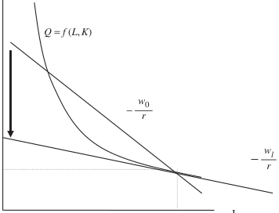

NOTE: figure/graphic rendered as an image from the PDF; its content is not machine-readable text. Caption (if any) follows as the next block.

**text found inside the figure**

*r w*0 −

*r wl* −

*Q* = *f* (*L*,*K*)

*r TC*0

*L*0

L

K

*r TCl*

*K*0

Figure 1 Relocation and the reduction of total production cost in country l.

164 K. Coucke et al.

Page 5

Figure 2 illustrates the reduction in cost as a result of downsizing through automation, starting from the same disequilibrium situation as before. The firm reduces its total production cost as a result of using capital more intensively.<sup>1</sup> The adjustment cost of downsizing l<sup>d</sup>

t <sup>depends</sup> <sup>on</sup> <sup>the</sup> <sup>variable</sup> <sup>RINV</sup><sup>t</sup><sup>1</sup><sup>,</sup> <sup>denoting</sup> <sup>the</sup> level of recent investments. We assume that l<sup>d</sup>

t<sup>.</sup> <sup>The</sup> <sup>higher</sup> <sup>the</sup> <sup>level</sup> <sup>of</sup> <sup>recent</sup> investments to obtain a more efficient technique, the more costly it will become to make further improvements.

Clearly, the firm will choose the mode of restructuring that minimizes net cost. For an infinite horizon, the choice between (labor) downsizing and relocation boils down to compare the discounted net cost of downsizing, (C <sup>d</sup> (w 0, r, Ld, Kd)/) þ l<sup>d</sup>, with the discounted net cost of relocation, (C <sup>l</sup> (w l, r, L l, K l)/) þ l<sup>l</sup>. The choice between downsizing and relocation thus results in a simple comparison of the difference in present value recurrent operating cost with the difference in adjustment costs of the two restructuring modes, multiplied with the discount rate. The condition for the choice to relocate can be written as

with Ll, Kl and l<sup>l</sup> denoting the input variables and adjustment costs in case of relocation while index d reflects the same variables for the downsizing mode. In order to arrive at some more insightful results concerning this choice criterion, we shall

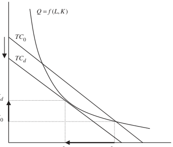

NOTE: figure/graphic rendered as an image from the PDF; its content is not machine-readable text. Caption (if any) follows as the next block.

**text found inside the figure**

*TCd*

*TC*0

*Q* = *f* (*L*,*K*)

*Kd*

*K*0

*L*0 *Ld*

*L*

*K*

Figure 2 Downsizing and the Reduction of Total Production Cost by Technique d.

1From an inefficient capital to labor ratio (K0/L0) after the shock to an efficient ratio (Kd/Ld).

Employee layoff under different modes of restructuring 165

Page 6

assume hereafter a standard constant elasticity of substitution (CES) production function Q ¼ A[K þ L]<sup>1/</sup>, homogenous of degree 1, linking inputs to output. The elasticity of substitution, s, equals 1/(1 ’).<sup>2</sup> It follows that for any given fixed output level, the firm will choose Ll, Kl such that it minimizes its production cost after relocation, according to the following first order condition for cost minimization

rK <sup>1</sup><sup>’</sup>

l : ð2Þ

If the firm opts for downsizing, the optimal choices for Ld, Kd are such that

rK <sup>1</sup><sup>’</sup>

d : ð3Þ

Substituting Kl, Kd from equations (2) and (3) in equation (1) shows that a firm prefers relocation to downsizing if<sup>3</sup>

r

Ld wl þ r <sup>w</sup><sup>l</sup>

r

: ð4Þ

The left side of this inequality reflects the reduction in total variable cost after a relocation to a lower wage country. The equation shows that it is not just the difference in wage and the total amount of labor drive the relocation decision, but also the elasticity of substitution, the cost of labor and the output elasticities.<sup>4</sup>

Taking the analysis one step further, to see how the decision to relocate depends on wage differences, we can express equation (4) in its reduced form. Solving the equation for optimal labor L in terms of the exogenous variables Q, w0, wl, r, the condition to relocate can be written as<sup>5</sup>

V1 ¼ <sup>Q</sup>

l 1= 1 ð Þ h i

The following proposition can be derived from equation (5).

Proposition 1: A firm’s probability to choose relocation over downsizing increases if (i) its production output increases, i.e (@v1/@Q)40; (ii) the cost of capital decreases,

2Recent literature (Klump and De La Granville, 2000; Papageorgiou and Saam, 2006; Dupuy and De Grip, 2006) has highlighted the role of the elasticity of substitution as a determinant of, among others, labor productivity, which affects the reorganization decision. In the limit, as ’ approaches 0, the production function takes the standard Cobb–Douglas form.

3If production function is Cobb–Douglas, the expression can be simplified to 1 <sup>w</sup><sup>0</sup><sup>L</sup><sup>d</sup> <sup>w</sup><sup>l</sup><sup>L</sup><sup>l</sup> ð Þ4ðll ldÞ:

4See also Konings (2004).

5Optimal input can be expressed as Ld ¼ ðQ=AÞðA=w0Þc

d with cd ¼ ð1=AÞðr<sup>1</sup> þ w<sup>1</sup>

o Þ<sup>1</sup><sup>=</sup><sup>ð</sup><sup>1</sup><sup>Þ</sup>. A similar expression can be derived for Ll.

166 K. Coucke et al.

Page 7

i.e. (@V1/@)40; (iii) the wage differential increases, so, given a constant w0, (@V1/@wl)40; (iv) production becomes more labor-intensive, as reflected by an increases in (and, by definition, a decrease in ), i.e. (@V1/@)40; (v) the elasticity of substitution increases<sup>6</sup>, i.e. (@V1/@s)40; and (vi) it has more experience in producing abroad such that the cost of relocation decreases, i.e. (@V1/@MNE)40.

Proof: (i) As the term in the square brackets is positive because of the lower labor cost abroad, the partial derivative is positive; (ii) As it is assumed that the fixed cost of relocation is greater than the fixed cost of downsizing, the partial derivative is positive; (iii) A decrease in the cost of labor abroad obviously decreases the total cost of production abroad; (iv) A more labor-intense production process aggravates the difference in wage cost between foreign and domestic production; (v) for s ¼ 0, wages do not have an impact on the capital to labor ratio and hence the cost reduction will be proportional to a fraction of the output; As s increases, more substitution will take place and cost reduction will be larger, with in the limit, as s ! 1, only labor being used as input. (vi) l<sup>1</sup> is decreasing in MNE, while ld is unaffected by MNE.

It follows that large firms, which are labor-intensive, can strongly increase their profits if they relocate to a country l where the wage wl is significantly lower than in the home country. This result is in line with Pennings and Sleuwaegen (2000). On the other hand, firms that can significantly substitute labor for capital can strongly increase their profits if they adapt to an automation of the production process. Considering the cost side of both restructuring modes, the difference between l<sup>l</sup>

t<sup>ð</sup><sup>MNE</sup><sup>t</sup><sup>,</sup><sup>RINV</sup><sup>t</sup><sup>1</sup><sup>Þ</sup> <sup>and</sup> <sup>l</sup><sup>d</sup>

t <sup>ð</sup><sup>RINV</sup><sup>t</sup><sup>1</sup><sup>Þ</sup> <sup>is</sup> <sup>mainly</sup> <sup>determined</sup> <sup>by</sup> <sup>the</sup> <sup>multinational</sup> character of the firm. The variable RINVt1, which reflects the level of recent investments is assumed to have a negative effect on both the decision to relocate or downsize. However, recent investment in plant and equipment involving important sunk costs would especially render the downsizing and exit decision less attractive (Hopenhayn, 1992; Lambson, 1991).

Finally, to complete the theoretical framework, we consider exit versus downsizing. It can be shown that the firm, producing with the same CES technology, prefers downsizing to exiting the market if the firm can obtain a price for the good pt, if

V2 ¼ Q pt <sup>1</sup>

l<sup>d</sup>

t <sup>l</sup><sup>e</sup>

t

where l<sup>e</sup>

t <sup>is the exit adjustment cost which equals the positive scrap value of the firm</sup> at time t. From equation (6) we derive the following proposition.

6The difference in labor costs between relocation and downscaling when only producing with labor as input must be strictly greater than (l<sup>l</sup> l<sup>d</sup>). Furthermore, it is assumed that there is always a region where labor cost is sufficiently low, so that a firm in the low-wage country only uses labor as input when labor and capital are perfect substitutes (s ! 1).

Employee layoff under different modes of restructuring 167

Page 8

Proposition 2: A firm’s probability to prefer downsizing to exiting the market increases if (i) its production output increases, i.e. (@V2/@Q)40; (ii) the cost of capital decreases, i.e. (@V2/@)40; (iii) the price of the produced good increases, i.e. (@V2/@p)40; (iv) the exit cost increases, i.e. ð@V2=@l<sup>e</sup>

t<sup>Þ</sup><sup>5</sup><sup>0;</sup> <sup>and</sup> <sup>(v)</sup> <sup>the</sup> <sup>elasticity</sup> <sup>of</sup> substitution increases, i.e. (@V2/@s)40.

Proof: Similar to the proof of Proposition 1.

It may appear that the assumption that technology and skills are equal among countries imposes strong restrictions on our model, especially if destination countries for relocation include developing countries. Indeed, if skilled and unskilled labor are imperfect substitutes and/or capital-skill complementarity exists, relocation to countries lacking skilled labor could become less attractive (see, e.g. Krusell et al., 2000). Likewise, reducing unskilled labor through using more capital, which increases the productivity of skilled labor, would favor the downsizing option more than it does in our model. Moreover, if technology adoption becomes endogenous and is allowed to differ across countries, the choice of technology will depend on absorptive capacities and availability of skills in relocation countries. In such case, the decision to relocate becomes a lot more complicated than merely an evaluation of cost differences. Dependent upon skill differences, the firm may choose to implement a different technology in the long run. In the short run, with the existing technology, the skill gap may negatively affect production<sup>7</sup> (see e.g. Caselli and Coleman, 2006, for an interesting model and implications of endogenous technology choice across countries).

Since, however, the largest part of relocations from Belgium concern relocations to other developed countries, (64% of all relocations), especially other EU countries, we expect our basic model to hold. In any case, in testing the model we have split the data set into firms that relocate to less developed countries and firms that relocate to developed countries. If technology/skill differences do play a major role we expect a different regime or rejection of the proposed model for the latter group of countries.

Moreover, in testing the model we needed to control for other factors beyond production and cost optimization. In addition to the neo-classical cost considerations made above, there exists an empirical and theoretical literature on the exit decision, which emphasizes other characteristics of the firm. In the widely acclaimed model of Jovanovic (1982), firms learn their relative efficiency and are forced to leave the industry when they cannot meet the required efficiency. As a result, small and young firms are more likely to exit from the industry. Furthermore, firms will also exit if other restructuring modes are either not feasible or too costly from a resource perspective. Young firms, for example, are often too inexperienced to take the risk to relocate their production process. At the same time, small and young firms will find it difficult and costly to further automate their production process and lack the

7We are grateful to an anonymous referee to point out this issue.

168 K. Coucke et al.

Page 9

managerial skills. Moreover, as argued before, the exit decision is strongly influenced by the sunkness of past investments. The more recently the firm has invested in resources, the less depreciated the resource base, and therefore the more sunk cost will be involved when stopping all activities. In a review of empirical papers on exit, Siegfried and Evans (1994) find evidence that, as predicted by theory, poor profitability, weak demand conditions, low capital intensity, and small firm size have a significant impact on the propensity to exit. In the next section, we shall test the impact of the different firm and industry characteristics on the decision how to restructure in an econometric set up of the theoretical framework.

#### 3. Econometric model

Econometrically the decision to choose among the alternative modes of restructuring is modeled following a multinomial logit model. The log likelihood of the multinomial logit model can be written as

¼

i¼1

X

j

yij ln Pij

,

where is the vector of coefficients, yij ¼ 1 if the i-th firm chooses restructuring mode j, and 0 otherwise, X is the matrix of explanatory variables, and

Pij ¼ expðX<sup>0</sup>

i<sup>j</sup><sup>Þ</sup>

i<sup>j</sup><sup>Þ</sup>

for j 2 l, d, e f g, and

for j ¼ o (reference group). The reference group is the group of firms that do not restructure during the observation period, i.e. those firms that cannot gain from any of the considered restructuring actions. Testing the various hypotheses, the following industry and firm characteristics are included as explanatory variables in the models.

3.1 Profitability and financial leverage

The most important factor in the decision to restructure has been hypothesized to be a lack of profitability as compared to similar firms operating in the same market. Shareholders will require clearly underperforming firms to restructure and to achieve a higher profitability. We include the return on equity (ROE) as a measure<sup>8</sup>

8For a precise definition of the explanatory variables and descriptive statistics, we refer to the Appendix.

Employee layoff under different modes of restructuring 169

Page 10

of profitability. Kang and Shivdasani (1997) find in a sample of Japanese manufacturing firms that return on equity has a significant negative impact on downsizing.

Together with poor performance, the financial structure of the firm has been hypothesized to affect the restructuring decision. Highly leveraged firms are more likely to restructure. Especially firms in financial distress underinvest in fixed assets (Myers, 1977) and have a higher propensity to restructure. Debtholders will exert pressure to layoff employees, liquidate or sell assets when the firm fails to meet its interest payments. Moreover, debt-holders, as being first on the creditors list, will fight against continued operation if the net value they receive from selling assets exceeds their expected proceeds from continued operations (Schary, 1991). The leverage ratio is defined as the ratio of the book value of debt to the sum of the value of debt and equity (LEV). Though theory predicts a positive sign between a firm’s restructuring decision and financial leverage, Schary (1991) surprisingly finds a negative sign of leverage in the cotton industry. Kovenock and Phillips (1997) do discover a positive relationship between leverage and exit, but significant only in highly concentrated industries. In the trucking industry, Zingales (1998) also finds a positive effect of leverage.

For downsizing, there are also mixed empirical results for the leverage variable. Ofek (1993) shows in a sample of US firms that restructuring measures, such as employee layoffs, are affected by capital structure. The latter finding confirms the argument by Jensen (1986) that highly leveraged firms will respond faster to a decline in firm value. Ofek (1993) reports a positive effect of leverage, while Kang and Shivdasani (1997) find a negative sign for a group of Japanese firms. Whereas the latter two empirical studies use a sample of firms that experienced a substantial decline in operating performance, our sample consists of firms reporting a layoff regardless of their profitability. In order to isolate the effect of leverage of firms in financial distress we construct a binary variable DIS which takes a value of 1 if a firm has a negative ROE in the year preceding the collective layoff and interact DIS with the leverage variable (LEV).

The learning theory of firms’ growth argues that young firms grow faster if they learn through market forces that they started with the right structure and their performance compares well with existing competitors. However, many young firms find out the contrary, and therefore will face more pressure to restructure than more experienced firms. We include the firm’s age (AGE) for experience.

Table A4 (Appendix) reports the total number of job losses for the different modes of employee layoffs across major sectors for Belgium during the period 1990–1999. The table suggests that manufacturing industries differ in the mode of restructuring from service industries. As compared to manufacturing firms, firms in service sectors experienced large growth rates between 1990 and 1999. Moreover, service sectors are primarily market oriented, and need a close connection with customers and hence will show a smaller probability to relocate. Variable MAN takes a value equal to one if the firm is in the manufacturing industry.

170 K. Coucke et al.

Page 11

3.2 Product differentiation and scale economies

As competitive pressure may be assumed less severe in industries characterized by product differentiation, the probability to restructure may on average be lower. We include the industry variable PRODIF which is proxied by the intra-industry trade index of Grubel and Lloyd (1975). The G-L index at the industry level (Marvel and Ray, 1987) can be defined as follows: G Li ¼ 2min(Xi, Mi)/(Xi þ Mi), where Xi equals total exports in industry i and Mi total imports in industry i. Many studies found the last variable to correlate strongly with product differentiation (Helpman, 1987; Bergstrand, 1990), though it may also be an indication of exposure to international competition.

With economies of scale present, volume advantages gain importance, and firms will be more likely to prefer to relocate total production to a location with lower production cost than to downsize and/or fragment its current operations. Downsizing would lower the effective output of the firm such that economies of scale at the plant or firm level would be lost. The variable for minimum efficient scale (MES) is defined as the log of the median size of firms in an industry. Instead of MES, Haynes et al. (2000) employ industry concentration, which should be highly correlated with MES, as explanatory variable and find a negative effect of the variable on divestment.

3.3 Size and labor-intensity

In accordance with the basic theoretical results, larger firms facing the need to restructure will choose to relocate part of their activity or to downsize instead of exiting from the market. As a consequence, we expect firm size to have a negative impact on exit and a positive impact on downsizing and relocation. We include the firm’s value added as a proxy of the SIZE of the firm.

Through its proximity to a mass market and its relatively high wage costs, Belgium has established a comparative advantage in capital-intensive industries (Tharakan and Waelbroeck, 1988; Sleuwaegen and De Backer, 2001). The variable C/L is a measure of the capital to labor ratio. Following our theoretical model, a low capital to labor ratio should increase the probability to relocate.

3.4 Recent investments

Investments in capital constitute a barrier to exit and downsizing, because of the important costs that are sunk in specific plant and equipment and intangible investments (Caves and Porter, 1976). The latter aspect may be better reflected by the variable RINV, measuring recent investments in capacity through the acquisitions of tangible assets. RINV has been hypothesized to limit the firm’s ability to restructure. The higher the amount of recent investments, the higher will be the adjustments costs to restructure, especially in the case of the exit mode. The more recently the

Employee layoff under different modes of restructuring 171

Page 12

firm has invested in resources, the less depreciated the resource base, and thus the higher the resale price required to make exit more attractive than continued operation (Harrigan, 1980). Especially investment in plant and equipment involving important sunk costs would render the downsizing or exit decision less attractive (Hopenhayn, 1992; Lambson, 1991). More recently, Dixit (1989) and Dixit and Pindyck (1994) demonstrated that in exploiting the option value of waiting the extent and timing of exit depends crucially on sunk costs and the degree of uncertainty about future profit opportunities. Lacking good alternative opportunities, firms will persist to operate even if profitability is low, causing a special type of hysteresis.

Clearly, not all firms have the same option to relocate capacity to another country, especially when setting up a foreign plant involves substantial sunk costs. We, therefore, expect those firms that already operate a multinational network to benefit from this location flexibility in reducing costs. Since the adjustment cost to relocate for those firms is strongly lowered by their operating flexibility, we assume that especially multinational firms will prefer relocation to downsizing or exit. The fact that they compare costs comparatively across the different plants makes also reported profitability of one production unit in a particular location, often influenced by transfer pricing techniques, a less good performance measure (Kogut and Kulatilaka, 1994; Pennings and Sleuwaegen, 2000). The dummy variable MNE distinguishes multinational firms from firms without a multinational production network (MNE ¼ 0).

#### 4. Data

In Belgium every firm with more than twenty employees needs to report a dismissal of more than 10% of the employees (a so-called collective layoff) at the Federal Government. Subsequently, the Federal Planning Bureau (FPB) in Belgium sends a questionnaire to the three Belgium unions. In the questionnaire it is asked if the layoff is motivated by relocation. This way there is a very good sample of all restructuring firms, the mode of restructuring, and the number of job losses involved. Between 1990 and 1999 a total number of 861 firms reported an amount of 1218 collective layoffs. At least one questionnaire was answered by 659 firms reporting a total of 827 collective layoffs. These numbers induce a 77% response rate at firm level and a 68% response rate for each collective layoff.

Within the sample exit, relocation, and downsizing account for 10%, 21%, and 69% of total job destruction, respectively. Though the figures do not include all restructuring within the sample period, it gives some intuition of the relative importance of the different modes of restructuring. Table A4 also indicates that the average number of job losses after restructuring is relatively small for exiting firms, but relatively large for relocating firms. Though job losses from

172 K. Coucke et al.

Page 13

relocation are substantial, it appears that the majority of employee layoffs are due to downsizing (without the subsequent transfer of production abroad).

As reference group, a total number of 2999 firms are randomly selected from the population of firms in Belgium that need to report financial statements<sup>9</sup> and having (like the group of firms that need to report a collective layoff) at least 20 employees. Needless to say, firms that are within the group of restructuring firms are not in the reference group.

Firm specific data are taken from the financial statements of the companies. Detailed data are available for 105 out of the 122 firms that relocated activities, for 97 out of the 123 that exited, and for 339 out of the 616 that downsized through collective layoff.<sup>10</sup> The same data are available for 2068 non-restructuring firms. For the group of restructuring firms, the firm characteristics (such as return on equity) refer to the balance sheet prior to the year of restructuring as to avoid endogeneity problems. Data for the non-restructuring firms are averaged over the period 1992–1994.<sup>11</sup> The industry characteristics are averaged over the observation period.

#### 5. Results

Table 1 presents the regression results for the multinomial model with nonrestructuring firms as the reference group. Table 2 tests for differences between the different restructuring modes, more closely related to the theoretical framework set up in this article.

The variables measuring the firm’s profitability both indicate that firms which layoff employees are not among the most profitable ones (Appendix). The coefficient measuring the sensitivity of restructuring to profitability losses is not significant for exiting firms. The rationale for this finding lies in the hysteresis phenomenon, described earlier. On the contrary, firms that downsize or relocate are sensitive to deteriorating profitability. Since the descriptive statistics in the Appendix suggest that relocating firms are the most profitable among the restructuring firms, firms having an option to relocate will do so when profitability significantly decreases.

The estimated parameter for the interaction variable LEV*DIS provides evidence that employee layoffs by poorly performing firms are positively linked

9This database is maintained by the National Institute of Statistics (NIS) in Belgium.

10We consider the year prior to the largest downsizing or relocation in cases where a firm reported several restructures. Firms reporting both relocation and downsizing within the sample period are omitted from the sample.

11As a robustness check, we have randomly selected a year for which data of the non-restructuring firms are taken. The significance of the variables appears not to depend on the selection and construction of the independent variables.

Employee layoff under different modes of restructuring 173

Page 14

[output not shown]

NOTE: table converted from PDF layout to HTML text; cell boundaries are reconstructed. See PDF if exact alignment matters.

Table 1 General results from multinomial logit regression

Relocating Exiting Downsizing Consolidated

Intercept 2.94 0.29 (1.46) 8.64*** 0.91 (4.19) 0.23*** 0.05 (0.19)

SIZE 0.34*** 0.02 (4.01) 0.46*** 0.06 (4.40) 0.21*** 0.03 (3.86) 0.14*** 0.02 (3.10)

C/L 0.32*** 0.02 (3.82) 0.37*** 0.03 (4.34) 0.04 0.01 (0.73) 0.16*** 0.09 (3.58)

MES 0.76*** 0.05 (4.24) 0.18 0.00 (0.89) 0.31*** 0.03 (2.83) 0.37*** 0.03 (3.95)

PRODIF 4.01** 0.20 (2.32) 1.71 0.01 (1.00) 4.04*** 0.51 (4.09) 3.72*** 0.45 (4.44)

MNE 1.03*** 0.08 (4.16) 0.23 0.01 (0.94) 0.09 0.01 (0.63) 0.30** 0.04 (2.50)

RINV 1.42*** 0.05 (2.84) 2.89*** 0.23 (5.17) 1.79*** 0.20 (5.81) 1.98*** 0.34 (7.74)

AGE 0.23 0.01 (1.18) 0.84*** 0.08 (4.83) 0.24** 0.02 (2.06) 0.37*** 0.03 (3.72)

ROE 0.20** 0.00 (2.10) 0.15 0.00 (1.47) 0.36*** 0.05 (6.36) 0.29*** 0.09 (6.05)

LEV*DIS 2.02*** 0.11 (5.70) 2.09*** 0.15 (6.07) 1.58*** 0.17 (7.14) 1.78*** 0.27 (9.28)

MAN 0.23 0.00 (1.02) 0.77*** 0.06 (3.18) 0.62*** 0.08 (4.61) 0.58*** 0.09 (5.12)

Log Lik 1540.06 1597.96

T-values are between brackets. Marginal effects on the probability are in italics.

*Significant at the 10% level; **significant at the 5% level; ***significant at the 1% level.

174 K. Coucke et al.

Page 15

to financial leverage. Furthermore, Table 2 shows that LEV*DIS is a significant variable in explaining the difference between downsizing and exiting firms. The result is in line with the theoretical prediction and most of the empirical results, as previously discussed.

Table 1 shows that manufacturing firms are more likely to restructure, and especially to layoff employees through downsizing or exit. The positive effect of the manufacturing variable is most prominent for downsizing firms. However, Table 2 reflects no significant different impact of MAN on the different restructuring modes.

The results show a clear distinction in the effect of firm size and firm age on the form of layoff. Consistent with the theory of selection effects associated with passive learning about initial conditions, the impact of firm size and age on exit is negative. Table 2 shows that the firm’s size is not a significant variable in explaining the difference between relocating and downsizing firms but the firm’s size is statistically different between downsizing and exiting firms, in line with our theoretical prediction. The table also shows that firms active in industries characterized by economies of scale prefer relocation to downsizing. No significant impact of scale economies are found in the choice between downsizing and exit in Table 2. Table 1 shows that the effect of age on relocation is not significant.

Firms and especially multinational firms that have the relocation option, will execute the option if wage or other costs become unfavorably high in a particular

Table 2 Results from the Multinomial Logit Regression with downsizing as reference group

[output not shown]

NOTE: table converted from PDF layout to HTML text; cell boundaries are reconstructed. See PDF if exact alignment matters.

T-values are between brackets. Marginal effects on the probability are in italics.

*Significant at the 10% level; **significant at the 5% level; ***significant at the 1% level.

Employee layoff under different modes of restructuring 175

Page 16

location (Kogut and Kulatilaka, 1994; Slaughter, 2000). Consistent with this reasoning and in line with proposition 1, Table 2 shows that the capital to labor ratio coefficient is significant and has the expected sign in explaining the choice between relocating and downsizing. Furthermore, labor-intensive firms that are not able to exploit Belgium’s comparative advantage in capital-intensive industries, and that are not able to relocate part of the labor-intensive activities abroad, are forced to exit.

Table 2 reflects significant differences in the adjustment costs of restructuring for different types of firms. The multinational character of a firm is a significant variable in explaining the difference between relocating and downsizing firms. Especially multinational firms relocate production activities abroad reflecting the strategic advantage of the operating flexibility of those firms.

The effect of stickiness of capital, RINV, on the decision to restructure is most apparent through its effect on exit and downsizing. The marginal effect of RINV on the probability to relocate is small, notwithstanding the higher rate of recent investments made by relocating firms (Appendix). This finding suggests that in being able to reemploy investment goods in another location, relocating firms are less constrained in their restructuring decisions than other firms. This result is in line with Hopenhayn (1992) and Lambson (1991) who found that investment in plant and equipment involving important sunk costs would especially render the exit decision less attractive.

Considering the impact of product differentiation, the results in Table 1 show that PRODIF has the expected sign. The strong negative effect of product differentiation on the decision to relocate, suggests the importance of specific market conditions in the location decision. The possibility of occupying a strategic niche in the market requires close market contact and renders a pure efficiency seeking strategy through relocation less attractive. Likewise, product differentiation leads to less downsizing, in line with the previous reasoning.

As a next step, as to test the validity of the model across developed and developing countries, we restrict the sample of relocating firms to those firms that move activities to low wage countries (Eastern Europe, North Africa, East Asia). The number of relocations to developing countries equals 38 out of the original sample of 105 firms. The results from the multinomial regression with the more narrow definition of relocation (Table 3), show that, in contrast with the previous table, size is a positive and significant determinant of the relocation versus downscaling decision. The intuition behind this significant difference is that firms relocating to low wage countries emphasize volume advantages in the relocation decision, in line with the theoretical model. So, whereas we previously rejected the hypothesis in Proposition 1 about the size effect, we now cannot reject the hypothesis. There are no major changes in the empirical estimates for the other variables, supporting the robustness of the results across countries.

176 K. Coucke et al.

Page 17

#### 6. Conclusions

Pro-active policies to deal with the negative consequences of collective employee layoffs necessitate a better understanding of the organizational and contextual features that influence the strategic decision process concerning relocation and downsizing of firms. The model and results presented in this study constitute an important step in helping to better understand and predict what firms will likely need to restructure and what mode of restructuring (relocation, downsizing, exit) will be chosen. We find the decision to restructure and layoff employees to relate strongly to industry wide and firm-specific features, including among others, the technological possibilities to work in a more capital-intensive way, the degree of product differentiation in the industry, the existence and experience with operating in multinational networks. For instance, firms having a well established multinational network will relocate sooner if profits start to decline than firms lacking such a network. All our results could be expanded in such an interpretative way, and lead to specific predictions concerning the likelihood of choosing among the alternative restructuring modes.

More specifically, the empirical results show that especially manufacturing firms characterized by a low profit performance and that are highly financially leveraged show a higher probability to restructure than other firms. Product differentiation

Table 3 Results from the Multinomial Logit Regression with relocation restricted to low wage countries

[output not shown]

NOTE: table converted from PDF layout to HTML text; cell boundaries are reconstructed. See PDF if exact alignment matters.

T-values are between brackets. Marginal effects on the probability are in italics.

*Significant at the 10% level; **significant at the 5% level; ***significant at the 1% level.

Employee layoff under different modes of restructuring 177

Page 18

appears to decrease the need to restructure. In line with the previous theory, large firms show a higher propensity to relocate or to downsize. Furthermore, at the industry level, economies of scale stimulate firms to relocate or downsize. Firms that are active in industries characterized by significant scale economies, have a higher propensity to relocate production. Labor-intensive firms that do not exploit Belgium’s comparative advantage in capital-intensive industries are forced to exit or, if possible, to relocate part of their labor-intensive activities abroad. The effect of stickiness of capital on the probability to relocate is small, notwithstanding the fact that relocating firms have invested more in the recent past. This finding suggests that in being able to reemploy investment goods in another location, relocating firms are less constrained in their restructuring decisions than other firms. The multinational character of a firm is one of the most important explanatory variables in explaining relocation behavior compared to other restructuring modes. The result strongly supports the concept of operating flexibility as a strategic advantage enjoyed by multinational firms.

Interpreting these results, we believe that our modeling approach has uncovered important antecedents influencing the strategic downsizing, relocation and exit process, in a way that they can be usefully integrated in a strategic decision making framework. A shortcoming in adopting our quantitative approach is that we sometimes had to use summary measures, e.g. poor financial performance, which in turn depends on a wide set of environmental variables, including the growth and degree of competition in the industry. Further research may refine these dimensions to uncover specific contextual drivers explaining the observed performance. We also believe that a qualitative research approach, in particular the development of specific case studies searching for evidence of the way in which, or in other words, ‘how’ relocation, downsizing and exit decisions are taken, could strengthen and refine our results.

#### Acknowledgements

We are grateful to Rene Belderbos, Aziz Naji and two anonymous referees for helpful comments and suggestions. We also like to thank Hilde Spinnewyn and Bart Van den Cruyce from the Federal Planning Bureau for kindly providing us with the data. This research was supported by the Belgian Federal Government (DWTC-project SE/01/003).

#### Addresses for correspondence

Kristien Coucke, EHSAL, Stormstraat 2, 1000 Brussel, Belgium, and Catholic University of Leuven. e-mail: Kristien.Coucke@ehsal.be Enrico Pennings, Erasmus University Rotterdam, Applied Economics H13-31, Burg. Oudlaan 50, 3062PA Rotterdam, Netherlands and Tinbergen Institute. e-mail: Pennings@few.eur.nl

178 K. Coucke et al.

Page 19

Leo Sleuwaegen, Catholic University of Leuven, Naamsestraat 69, 3000 Leuven, Belgium, VLGMS and Erasmus University Rotterdam. e-mail: Leo.Sleuwaegen@ econ.kuleuven.ac.be

#### References

Bergstrand, J. H. (1990), ‘The Heckscher-Ohlin-Samuelson Model, the Linder hypothesis and

the determinants of bilateral intra-industry trade,’ Economic Journal, 100, 1216–1229.

Caselli, F. and J. Coleman (2006), ‘World technology frontier,’ NBER Working Paper 7904,’

American Economic Review, 96, 499–522.

Cascio, W. (1993), ‘Downsizing: what do we know? What have we learned?,’ Academy of

Management Executive, 7, 95–104.

Caves, R. and M. R. Porter (1976) in R. Masson and P. Qualss (eds), Barriers to Exit, in Essays

in Industrial Organization in Honor of Joe Bain. Ballinger: Cambridge MA, pp. 39–70.

Dewitt, R. L. (1993), ‘The structural consequences of downsizing,’ Organization Science, 4(1),

30–40.

Dewitt, R. L. (1998), ‘Firm, industry, and strategy influences on choice of downsizing

approach,’ Strategic Management Journal, 19, 59–79.

Dixit, A. (1989), ‘Entry and exit decisions under uncertainty,’ Journal of Political Economy, 97,

620–638.

Dixit, A. and R. Pindyck (1994), Investment under Uncertainty. Princeton University Press:

Princeton.

Dupuy, A. and A. De Grip (2006), ‘Elasticity of substitution and productivity, capital and skill

intensity differences across firms,’ Economics Letters, 90, 340–347.

Freeman, S. and K. Cameron (1993), ‘Organizational downsizing: a convergence and

reorientation framework,’ Organization Science, 4, 10–29.

Grubel, H. G. and P. J. Lloyd (1975), Intra-industry Trade: The Theory and Measurement of

International Trade in Differentiated Products. London: John Wiley & Sons.

Harrigan, K. R. (1980), ‘The effect of exit barriers upon strategic flexibility,’ Strategic

Management Journal, 1, 165–176.

Haynes, M., S. Thompson and M. Wright (2000), ‘The Determinants of corporate divestment

in the UK,’ International Journal of Industrial Organization, 18, 1201–1222.

Helpman, E. (1987), ‘Imperfect competition and international trade: evidence from fourteen

economies,’ Journal of the Japanese and International Economies, 1, 62–81.

Hopenhayn, H. (1992), ‘Entry, exit, and firm dynamics in long run equilibrium,’ Econometrica,

60, 1127–1150.

Jensen, M. (1986), ‘Agency costs of free cash flow, corporate finance, and takeovers,’ American

Economic Review, 76, 323–329.

Jovanovic, B. (1982), ‘Selection and the evolution of industry,’ Econometrica, 50, 649–670.

Employee layoff under different modes of restructuring 179

Page 20

Kang, J.-K. and A. Shivdasani (1997), ‘Corporate restructuring during performance declines in

Japan,’ Journal of Financial Economics, 46, 29–65.

Klump, R. and O. De La Granville (2000), ‘Economic growth and the elasticity

of substitution: two theorems and some suggestions,’ American Economic Review, 90, 282–291.

Kogut, B. and N. Kulatilaka (1994), ‘Operating flexibility, global manufacturing, and the

option value of a multinational network,’ Management Science, 40, 123–139.

Konings, J. (2004), Do Wage Differences Lead to Relocation: Comparative Analysis of High and

Low Wage Regions. Catholic University of Leuven: Mimeo, LICOS.

Kovenock, D. and G. Phillips (1997), ‘Capital structure and product market behavior: an

examination of plant exit and investment decisions,’ Review of Financial Studies, 10, 767–803.

Krusell, L., L. E., Ohanian, J. Rios-Rull and G. L. Violante (2000), ‘Capital-skill com-

plementarity and inequality: a macroeconomic analysis,’ Econometrica, 68, 1029–1053.

Lambson, V. (1991), ‘Industry evolution with sunk costs and uncertain market conditions,’

International Journal of Industrial Organization, 9, 171–196.

Marvel, H. J. and E. J. Ray (1987), ‘Intra-industry trade: sources and effects on protection,’

Journal of Political Economy, 95, 1278–1291.

Motta, M. and J. F. Thisse (1994), ‘Does environmental dumping lead to delocation?,’

European Economic Review, 38, 563–576.

Myers, S. C. (1977), ‘Determinants of corporate borrowing,’ Journal of Finance, 5, 147–175.

Ofek, E. (1993), ‘Capital structure and firms response to poor performance,’ Journal of

Financial Economics, 34, 3–30.

Papageorgiou, C. and M. Saam (2006), ‘Two-Level CES production technology in the solow

and diamond growth models,’ Working Paper, Louisiana State University.

Pennings, E. and L. Sleuwaegen (2000), ‘International relocation: firm and industry

determinants,’ Economics Letters, 67, 179–186.

Schary, M. A. (1991), ‘The probability of exit,’ Rand Journal of Economics, 22, 339–353.

Siegfried, J. J. and L. Beth Evans (1994), ‘Empirical studies of entry and exit: a survey of the

evidence,’ Review of Industrial Organization, 9, 121–155.

Slaughter, M. J. (2000), ‘Production transfer within multinational enterprises and American

wages,’ Journal of International Economics, 50, 449–472.

Sleuwaegen, L. and K. De Backer (2001), ‘Multinational enterprises, market integration and

trade structure: what remains of the standard goods hypothesis,’ Weltwirtschaftliches Archiv, 137, 379–403.

Tharakan, P. and J. Waelbroeck (1988), ‘Has human capital become a scarce factor in

Belgium,’ Cahiers Economiques de Bruxelles, 118, 159–179.

Zingales, L. (1998), ‘Survival of the fittest or the fattest? exit and financing in the trucking

industry,’ Journal of Finance, 53, 905–938.

180 K. Coucke et al.

Page 21

Table A1 Definition of explanatory variables

| Variable | Definition |
| --- | --- |
| SIZE | Thelogarithmofthefirm’saddedvalue . |
| C/L | Thelogarithmoftheratiooffixedcapitaltothenumberofemployeesinfulltime |
|  | equivalents . |
| MES | Minimumefficientscale definedasthelogofthemediansizeoffirmsintheindustry , |
|  | inwhichthefirmhasitsprimaryactivity Thefollowingindustriesaredefined: . |
|  | Primaryindustriesandmining;Food beveragesandtobacco;Textiles leather and , , , |
|  | wood; Cokes and chemicals; Rubber and plastics; Other non-metallic products; |
|  | Metals;Machineryandequipment;Electricalequipment;Transportequipment; |
|  | Construction;Wholesaling;Retailing;Hotels restaurantsandrecreation;Financial , |
|  | andotherservices . |
| MNE | Dummyvariable whichis1ifthefirmbelongstoaninternationalnetwork , . |
| RINV | Thelogarithmofthesumof1andtheratiooftheacquisitionoftangibleassetsto |
|  | thetangibleassetsattheendoftheprecedingperiod . |
| AGE | Thelogarithmoftheageofthefirmmeasuredinyearsupto1999 . |
| ROE | The return on equity (x) before taxes in five classes (1: x5 0 .16 , |
|  | 2: 0 .165x5 0 .08 3: 0 .085x50 .08 4: 0 .085x50 .16 5: 0 .165x) , , , . |
| DIS | Dummy variable which is 1 if return on equity is smaller than 0 .08 . |
| LEV | Theratioofdebttothesumofdebtandequity . |
| MAN | Dummyvariable whichis1formanufacturingindustries , . |
| PRODIF | The level of product differentiation reflected by the intra-industry trade index of |
|  | GrubelandLloyd(1975) . |

NOTE: table converted from PDF layout to HTML text; cell boundaries are reconstructed. See PDF if exact alignment matters.

Table A2 Descriptive statistics of explanatory variables

[output not shown]

NOTE: table converted from PDF layout to HTML text; cell boundaries are reconstructed. See PDF if exact alignment matters.

Employee layoff under different modes of restructuring 181

Page 22

Table A3 Correlation matrix of the total sample of firms

[output not shown]

NOTE: table converted from PDF layout to HTML text; cell boundaries are reconstructed. See PDF if exact alignment matters.

Table A4 Number of restructuring firms and layoffs across different sectors

| Industry sectors (NACE -code) | Exit | Relocation | Downsizing | Totals |
| --- | --- | --- | --- | --- |
|  | #firms(%) | #firms(%) | #firms(%) |  |
|  | #ofjobs(%) | #ofjobs(%) | #ofjobs(%) |  |
| Energyandwater(0&1) | 1(11%) | 0(0%) | 8(89%) | 9(1%) |
|  | 192(23%) | 0(0%) | 658(77%) | 850(1%) |
| Steel and non-metallic mineral | 14(19%) | 5(7%) | 56(75%) | 75(9%) |
| productsindustry(2223&24) , | 1344(10%) | 685(5%) | 11338(85%) , | 13367(16%) , |
| Chemicalindustry(25) | 5(9%) | 13(25%) | 35(66%) | 53(6%) |
|  | 300(8%) | 1428(37%) | 2103(55%) | 3831(5%) |
| Metallurgicindustry(3) | 18(10%) | 23(13%) | 140(77%) | 181(21%) |
|  | 2119(8%) | 6854(27%) | 16537(65%) , | 25510(31%) , |
| OtherIndustry:primarilyfood , | 30(12%) | 52(21%) | 164(67%) | 246(29%) |
| textile paper andrubber(4) , , | 1640(11%) | 6641(43%) | 7296(47%) | 15577(19%) , |
| Construction(5) | 4(15%) | 0(0%) | 22(85%) | 26(3%) |
|  | 131(8%) | 0(0%) | 1465(92%) | 1596(2%) |
| Distribution(6) | 23(16%) | 22(15%) | 97(68%) | 142(16%) |
|  | 1112(9%) | 1266(10%) | 10492(82%) , | 12870(16%) , |
| Transport communicationand , | 28(22%) | 7(5%) | 94(73%) | 129(15%) |
| financial otherservices , |  |  |  |  |
| (78&9) , | 1259(15%) | 383(5%) | 6649(80%) | 8291(10%) |
| Total | 123(14%) | 122(14%) | 616(72%) | 861 |
|  | 8097(10%) | 17257(21%) , | 56538(69%) , | 81892 , |

NOTE: table converted from PDF layout to HTML text; cell boundaries are reconstructed. See PDF if exact alignment matters.

182 K. Coucke et al.